# 1. Assessment of the Walleye Pollock Stock in the Gulf of Alaska

# Tables

(#tab:t.catch)Walleye pollock catch (t) in the Gulf of Alaska. The ABC is for the area west of 140W lon. (Western, Central and West Yakutat management areas) and includes the guideline harvest level for the state-managed fishery in Prince William Sound. Research catches are reported in Appendix 1E.

| Year | Foreign | Joint Venture | Domestic | Total | ABC/TAC |
| --- | --- | --- | --- | --- | --- |
| 1964 | 1,126 |  |  | 1,126 |  |
| 1965 | 2,746 |  |  | 2,746 |  |
| 1966 | 8,914 |  |  | 8,914 |  |
| 1967 | 6,272 |  |  | 6,272 |  |
| 1968 | 6,137 |  |  | 6,137 |  |
| 1969 | 17,547 |  |  | 17,547 |  |
| 1970 | 9,331 |  | 48 | 9,379 |  |
| 1971 | 9,460 |  | 0 | 9,460 |  |
| 1972 | 38,128 |  | 3 | 38,131 |  |
| 1973 | 44,966 |  | 27 | 44,993 |  |
| 1974 | 61,868 |  | 37 | 61,905 |  |
| 1975 | 59,504 |  | 0 | 59,504 |  |
| 1976 | 86,520 |  | 211 | 86,731 |  |
| 1977 | 117,833 |  | 259 | 118,092 | 150,000 |
| 1978 | 94,223 |  | 1,184 | 95,408 | 168,800 |
| 1979 | 103,278 | 577 | 2,305 | 106,161 | 168,800 |
| 1980 | 112,996 | 1,136 | 1,026 | 115,158 | 168,800 |
| 1981 | 130,323 | 16,856 | 639 | 147,818 | 168,800 |
| 1982 | 92,612 | 73,918 | 2,515 | 169,045 | 168,800 |
| 1983 | 81,318 | 134,171 | 136 | 215,625 | 256,600 |
| 1984 | 99,259 | 207,104 | 1,177 | 307,541 | 416,600 |
| 1985 | 31,587 | 237,860 | 17,453 | 286,900 | 305,000 |
| 1986 | 114 | 62,591 | 24,205 | 86,910 | 116,000 |
| 1987 |  | 22,822 | 45,248 | 68,070 | 84,000 |
| 1988 |  | 152 | 63,239 | 63,391 | 93,000 |
| 1989 |  |  | 75,585 | 75,585 | 72,200 |
| 1990 |  |  | 88,269 | 88,269 | 73,400 |
| 1991 |  |  | 100,488 | 100,488 | 103,400 |
| 1992 |  |  | 90,858 | 90,858 | 87,400 |
| 1993 |  |  | 108,909 | 108,909 | 114,400 |
| 1994 |  |  | 107,335 | 107,335 | 109,300 |
| 1995 |  |  | 72,618 | 72,618 | 65,360 |
| 1996 |  |  | 51,263 | 51,263 | 54,810 |
| 1997 |  |  | 90,130 | 90,130 | 79,980 |
| 1998 |  |  | 125,460 | 125,460 | 124,730 |
| 1999 |  |  | 95,638 | 95,638 | 94,580 |
| 2000 |  |  | 73,080 | 73,080 | 94,960 |
| 2001 |  |  | 72,077 | 72,077 | 90,690 |
| 2002 |  |  | 51,934 | 51,934 | 53,490 |
| 2003 |  |  | 50,684 | 50,684 | 49,590 |
| 2004 |  |  | 63,844 | 63,844 | 65,660 |
| 2005 |  |  | 80,978 | 80,978 | 86,100 |
| 2006 |  |  | 71,976 | 71,976 | 81,300 |
| 2007 |  |  | 52,714 | 52,714 | 63,800 |
| 2008 |  |  | 52,584 | 52,584 | 53,590 |
| 2009 |  |  | 44,247 | 44,247 | 43,270 |
| 2010 |  |  | 76,748 | 76,748 | 77,150 |
| 2011 |  |  | 81,503 | 81,503 | 88,620 |
| 2012 |  |  | 103,954 | 103,954 | 108,440 |
| 2013 |  |  | 96,363 | 96,363 | 113,099 |
| 2014 |  |  | 142,640 | 142,640 | 167,657 |
| 2015 |  |  | 167,549 | 167,549 | 191,309 |
| 2016 |  |  | 177,129 | 177,129 | 254,310 |
| 2017 |  |  | 186,155 | 186,155 | 203,769 |
| 2018 |  |  | 158,070 | 158,070 | 161,492 |
| 2019 |  |  | 120,243 | 120,243 | 135,850 |
| 2020 |  |  | 107,471 | 107,471 | 108,494 |
| 2021 |  |  |  |  | 105,722 |
| 2022 |  |  |  |  |  |
| Average (1977-2020) |  |  |  | 109,514 | 125,850 |

[output not shown]

# Figures

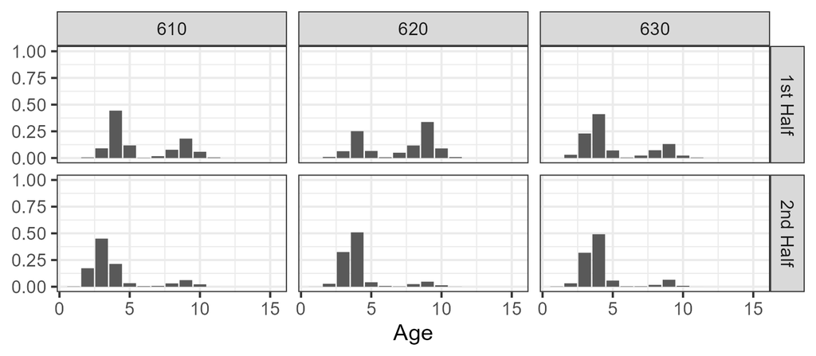

# Appendix 1a. Supplemental catch data

In order to comply with the Annual Catch Limit (ACL) requirements, a dataset has been generated to help estimate total catch and removals from NMFS stocks in Alaska. This dataset estimates total removals that occur during non-directed groundfish fishing activities. This includes removals incurred during research, subsistence, personal use, recreational, and exempted fishing permit activities, but does not include removals taken in fisheries other than those managed under the groundfish FMP. These estimates represent additional sources of removals to the existing Catch Accounting System estimates. For Gulf of Alaska (GOA) northern rockfish, these estimates can be compared to the research removals reported in previous assessments (Heifetz et al. 2009; Table 10 A-1). Northern rockfish research removals are minimal relative to the fishery catch and compared to the research removals of other species. The majority of research removals are taken by the Alaska Fisheries Science Center’s (AFSC) biennial bottom trawl survey which is the primary research survey used for assessing the population status of northern rockfish in the GOA. Other research activities that harvest northern rockfish include longline surveys by the International Pacific Halibut Commission and the AFSC and the State of Alaska’s trawl surveys. Recreational harvest of northern rockfish rarely occurs. Total removals from activities other than a directed fishery have been near 10 t for 2010 – 2017. The 2017 other removals is <1% of the 2018 recommended ABC of 4,529 t and represents a very low risk to the northern rockfish stock. Research harvests from trawl in recent years are higher in odd years due to the biennial cycle of the AFSC bottom trawl survey in the GOA and have been less than 10 t except in 2013 when 18 t were removed. These removals do not pose a significant risk to the northern rockfish stock in the GOA.

## References

Heifetz, J., D. Hanselman, J. N. Ianelli, S. K. Shotwell, and C. Tribuzio. 2009. Gulf of Alaska northern rockfish. In Stock assessment and fishery evaluation report for the groundfish resources of the Gulf of Alaska as projected for 2010. North Pacific Fishery Management Council, 605 W 4th Ave, Suite 306 Anchorage, AK 99501. pp. 817-874.

# Appendix 10b: VAST model-based abundance

## Background

The performance of VAST has been evaluated previously using a variety of designs.  
Research has showed improved performance estimating relative abundance compared with spatially-stratified index standardization models (Grüss and Thorson 2019; Thorson *et al*. 2015), while other simulation studies have shown unbiased estimates of abundance trends (Johnson *et al*. 2019).  
Brodie *et al*. (2020) showed improved performance in estimating index scale given simulated data relative to generalized additive and machine learning models.  
Using real-world case studies, Cao *et al*. (2017) showed how random variation in the placement of tows relative to high-quality habitat could be “controlled for” using a spatio-temporal framework, and OLeary *et al*. (2020) showed how combining surveys from the eastern and northern Bering Sea within a spatio-temporal framework could assimilate spatially unbalanced sampling in those regions. Other characteristics of model performance have also been simulation-tested although these results are not discussed further here.

## Settings used in 2020

The software versions of dependent programs used to generate VAST estimates were:

`R (>=3.5.3), INLA (18.07.12), TMB (1.7.15), TMBhelper (1.2.0), VAST (3.3.0), FishStatsUtils (2.5.0), sumfish (3.1.22)`

We used a Poisson-link delta-model (Thorson 2018) involving two linear predictors, and a gamma distribution for the distribution of positive catch rates. We extrapolated catch density using 3705 m (2 nmi) X 3705 m (2 nmi) extrapolation-grid cells; this results in 36,690 extrapolation-grid cells for the eastern Bering Sea, 15,079 in the northern Bering Sea and 26,510 for the Gulf of Alaska (some Gulf of Alaska analyses eliminated the deepest stratum with depths >700 m because of sparse observations, resulting in a 22,604-cell extrapolation grid). We used bilinear interpolation to interpolate densities from 500 “knots” to these extrapolation-grid cells (i.e, using `fine_scale=TRUE` feature); knots were distributed spatially in proportion to the distribution of extrapolation-grid cells (i.e., having an approximately even distribution across space) using `knot_method = 'grid'`. No temporal smoothing was used (i.e. variation was estimated using independent and identically distributed methods). We estimated “geometric anisotropy” (the tendency for correlations to decline faster in some cardinal directions than others), and included a spatial and spatio-temporal term for both linear predictors.  
Finally, we used epsilon bias-correction to correct for retransformation bias (Thorson and Kristensen 2016).

### Diagnostics

For each model, we confirm that the Hessian matrix is positive definite and the gradient of the marginal likelihood with respect to each fixed effect is near zero (absolute value < 0.0001).  
We then conduct a visual inspection of the quantile-quantile plot for positive catch rates to confirm that it is approximately along the one-to-one line, and also check the frequency of encounters for data binned based on their predicted encounter probability (which again should be along the one-to-one line).  
Finally, we plot Pearson residuals spatially, to confirm that there is no residual pattern in positive and negative residuals.

## References

Brodie, S.J., Thorson, J.T., Carroll, G., et al. (2020) Trade-offs in covariate selection for species distribution models: A methodological comparison. Ecography 43, 11–24.

Cao, J., Thorson, J., Richards, A. and Chen, Y. (2017) Geostatistical index standardization improves the performance of stock assessment model: An application to northern shrimp in the Gulf of Maine. Canadian Journal of Fisheries and Aquatic Sciences.

Grüss, A. and Thorson, J.T. (2019) Developing spatio-temporal models using multiple data types for evaluating population trends and habitat usage. ICES Journal of Marine Science 76, 1748–1761.

Helser, T.E., Punt, A.E. and Methot, R.D. (2004) A generalized linear mixed model analysis of a multi-vessel fishery resource survey. Fisheries Research 70, 251–264.

Johnson, K.F., Thorson, J.T. and Punt, A.E. (2019) Investigating the value of including depth during spatiotemporal index standardization. Fisheries Research 216, 126–137.

Lo, N.C.-h., Jacobson, L.D. and Squire, J.L. (1992) Indices of relative abundance from fish spotter data based on delta-lognornial models. Canadian Journal of Fisheries and Aquatic Sciences 49, 2515–2526.

Maunder, M.N. and Punt, A.E. (2004) Standardizing catch and effort data: A review of recent approaches. Fisheries research 70, 141–159.

O’Leary, C.A., Thorson, J.T., Ianelli, J.N. and Kotwicki, S. Adapting to climate-driven distribution shifts using model-based indices and age composition from multiple surveys in the walleye pollock (gadus chalcogrammus) stock assessment. Fisheries Oceanography.

Shelton, A.O., Thorson, J.T., Ward, E.J. and Feist, B.E. (2014) Spatial semiparametric models improve estimates of species abundance and distribution. Canadian Journal of Fisheries and Aquatic Sciences 71, 1655–1666.

Stefánsson, G. (1996) Analysis of groundfish survey abundance data: Combining the GLM and delta approaches. ICES journal of Marine Science 53, 577–588.

Thorson, J.T. (2018) Three problems with the conventional delta-model for biomass sampling data, and a computationally efficient alternative. Canadian Journal of Fisheries and Aquatic Sciences 75, 1369–1382.

Thorson, J.T. and Barnett, L.A. (2017) Comparing estimates of abundance trends and distribution shifts using single-and multispecies models of fishes and biogenic habitat. ICES Journal of Marine Science 74, 1311–1321.

Thorson, J.T. and Kristensen, K. (2016) Implementing a generic method for bias correction in statistical models using random effects, with spatial and population dynamics examples. Fisheries Research 175, 66–74.

Thorson, J.T., Shelton, A.O., Ward, E.J. and Skaug, H.J. (2015) Geostatistical delta-generalized linear mixed models improve precision for estimated abundance indices for West Coast groundfishes. ICES Journal of Marine Science 72, 1297–1310.

Thorson, J.T. and Ward, E.J. (2013) Accounting for space–time interactions in index standardization models. Fisheries Research 147, 426–433.